# ANOVA with R

Summer Schools on Pollination Ecology, 2018

## Goals for this lab

- Understand why we use ANOVA to answer scientific questions
- Learn how to use ANOVA in R

## Motivation, PD & PL - 1

In the field, you conducted **breeding system** and **pollen supplementation experiments**.

**Breeding system experiments: measure pollinator dependence (PD)**

- quantify the reliance of a plant species on pollinators for reproduction

**Supplementation experiments: measure pollen limitation (PL)**

- quantify the magnitude by which plant reproduction is limited by pollen receipt from pollinators

Use ANOVA to ask whether plants are **pollinator dependent** and/or **pollen limited** (compare *bagged*, *control* and *supplement* treatments).

## Motivation, PD & PL - 2

Situations you may encounter when measuring reproductive success:

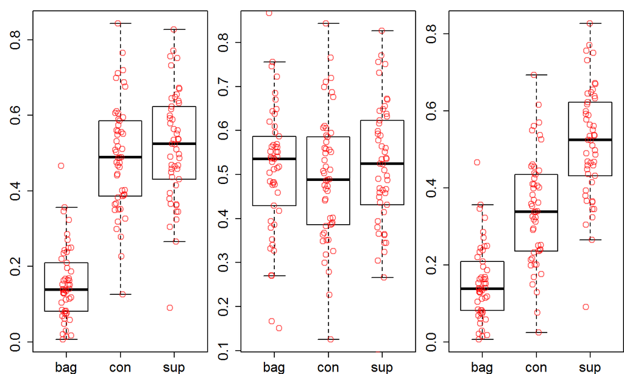

## Motivation, PD & PL - 3

**Pollinator dependence (PD)** & **pollen limitation (PL)** based on a reproductive success measure (e.g ratio between viable seeds and total number of ovules)

| pollinator dependence (PD) | pollen limitation (PL) |
| --- | --- |
| if bag < sup | if con < sup |

**Auto-fertility index (AFI)**

- AFI is the ratio of average reproductive success in bagged vs. supplement.
- PD if AFI < 0.2

**Magnitude (effect size) of PL (the log response ratio)**

- `ES = ln(reproductive success in supplement treatment) - ln(reproductive success in control treatment)`
- A low value (close to 0) indicates no PL

## Motivation, PD & PL - 3

| pollinator dependence (PD) | pollen limitation (PL) |
| --- | --- |
| if bag < sup | if con < sup |

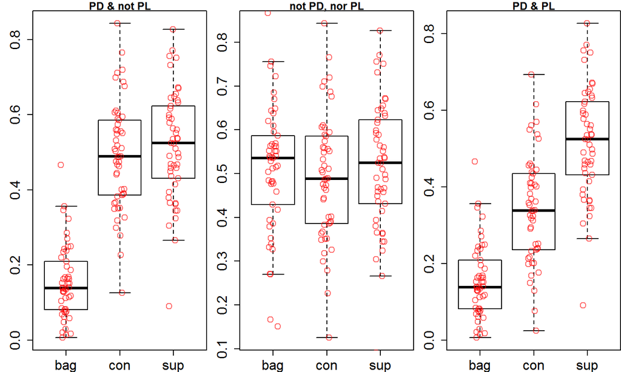

## ANalysis Of VAriance (ANOVA)

How many means do you compare?

- 2 means - **t-test**
- more than 2 means - **ANOVA** (bag, cont, sup)

Note - can also use ANOVA for two means. But it is standard practice to use t-test in such cases.

ANOVA

- **Null Hypothesis (H0)**: no difference between the group means
- **Alternative hypothesis (H1)**: means are different (do further tests to see which ones)

Next - an example with R.

## Outline of the exercise

- Read data
- Check assumptions (because ANOVA is a “parametric” test)
  - normality
  - homogeneity of variance
- ANOVA summary: are there differences or not?
- “post hoc” tests: where are the differences?